# Florence Nightingale Competition 2020 - RLadies Spain

Authors: Laura Ventosa and Esther Manzano

July 2020

# 1 Introduction

**Florence Nightingale** (1820-1910), known as *The Lady With the Lamp*, was a British nurse, social reformer and statistician best known as the founder of modern nursing. Her experience as a nurse during the Crimean War was foundational in her views about sanitation. She established St. Thomas’ Hospital and the Nightingale Training School for Nurses in 1860. Her efforts to reform healthcare greatly influenced the quality of care in the 19th and 20th centuries.

In 1854, she and 38 other nurses trained by herself traveled to the Crimean peninsula to treat the wounded British soldiers in the Crimean War (October 1853 - March 1856). After their arrival, the nurses discovered that the treatments the injured soldiers were receiving were inaccurate and that the overall hygenic conditions and medical supplies were insufficient. Florence kept a record of the monthly deaths by injuries, zymotic diseases and other causes among the soldiers between April 1854 and March 1856.

One of her most important discoveries was the fact that “deaths caused by diseases were more than seven times the number of deaths due to combat”, the reason being unsanitary hospital conditions. However, knowing numbers alone have limited persuasive powers, Nightingale used her skills in statistical communication to convince the British parliament of the need to act. She avoided the dry tables used by most statisticians at the time, and instead devised a novel graph, polar-area diagram, to illustrate the impact of hospital and nursing practice reform on army mortality rates.

# 2 Data Exploration

In this first section, we will check the different types of data on our dataset. We want to understand the nature of our variables (i.e. the proportion of numerical and categorical variables) to be able to develope a better model afterwards. In addition, we will check on missing values and outliers.

## 2.1 Basic Information

The following table shows the first rows of our dataset, including the names of the variables we have worked with.

```
## # A tibble: 6 x 8
##   Month `Average size o… `Zymotic diseas… `Wounds & injur… `All other caus…
##   <chr>            <dbl>            <dbl>            <dbl>            <dbl>
## 1 Apr …             8571                1                0                5
## 2 May …            23333               12                0                9
## 3 Jun …            28333               11                0                6
## 4 Jul …            28722              359                0               23
## 5 Aug …            30246              828                1               30
## 6 Sep …            30290              788               81               70
## # … with 3 more variables: `Zymotic diseases...6` <dbl>, `Wounds &
## #   injuries...7` <dbl>, `All other causes...8` <dbl>
```

```
## [1] 24  8
```

We can observe that the dimensions of our original dataset are 24x8. That is, 24 rows and 8 columns.

```
##                 Month  Average size of army  Zymotic diseases...3
##           "character"             "numeric"             "numeric"
## Wounds & injuries...4  All other causes...5  Zymotic diseases...6
##             "numeric"             "numeric"             "numeric"
## Wounds & injuries...7  All other causes...8
##             "numeric"             "numeric"
```

```
##     Month           Average size of army Zymotic diseases...3
##  Length:24          Min.   : 8571        Min.   :   1.00
##  Class :character   1st Qu.:30211        1st Qu.:  78.75
##  Mode  :character   Median :32586        Median : 429.50
##                     Mean   :34976        Mean   : 603.17
##                     3rd Qu.:43284        3rd Qu.: 808.50
##                     Max.   :47751        Max.   :2761.00
##  Wounds & injuries...4 All other causes...5 Zymotic diseases...6
##  Min.   :  0.00        Min.   :  5.00       Min.   :   1.40
##  1st Qu.:  0.75        1st Qu.: 22.25       1st Qu.:  21.82
##  Median : 45.00        Median : 32.50       Median : 139.95
##  Mean   : 73.25        Mean   : 72.83       Mean   : 221.51
##  3rd Qu.:118.50        3rd Qu.: 79.00       3rd Qu.: 316.27
##  Max.   :287.00        Max.   :361.00       Max.   :1022.80
##  Wounds & injuries...7 All other causes...8
##  Min.   :  0.00        Min.   :  2.500
##  1st Qu.:  0.30        1st Qu.:  6.925
##  Median : 14.95        Median :  9.850
##  Mean   : 24.22        Mean   : 26.958
##  3rd Qu.: 38.70        3rd Qu.: 31.475
##  Max.   :115.80        Max.   :140.100
```

Nightingale’s original dataset consists of the following variables:

- Month (1): Character variable stating the month and year (period).
- Average size of army (2): Numeric variable that informs the reader about the average size of the army in such period of time.
- Zymotic diseases (3): Numeric variable which states the number of soldiers who died in such period of time for zymotic disease causes in absolute values.
- Wounds & injuries (4): Numeric variable which indicates the number of soldiers who died in such period of time for wounds and injuries causes in absolute values.
- All other causes (5): Numeric variable which shows the number of soldiers who died in such period of time for any other causes in absolute values.
- Zymotic diseases (6): Numeric variable which states the number of soldiers who died in such period of time for zymotic disease causes in rate values.
- Wounds & injuries (7): Numeric variable which indicates the number of soldiers who died in such period of time for wounds and injuries causes in rate values.
- All other causes (8): Numeric variable which shows the number of soldiers who died in such period of time for any other causes in rate values.

In order to make the data more readeable and understandable, we will make some changes in the variables as well as some variable additions.

## 2.2 Missing Values and Outliers

We are interested in knowing whether we have missing observations before start treating our data.

```
##         month avg_size_army       zymotic      injuries         other
##             0             0             0             0             0
##  zymotic_rate injuries_rate    other_rate
##             0             0             0
```

As we can see, there are no missing values in our dataset.

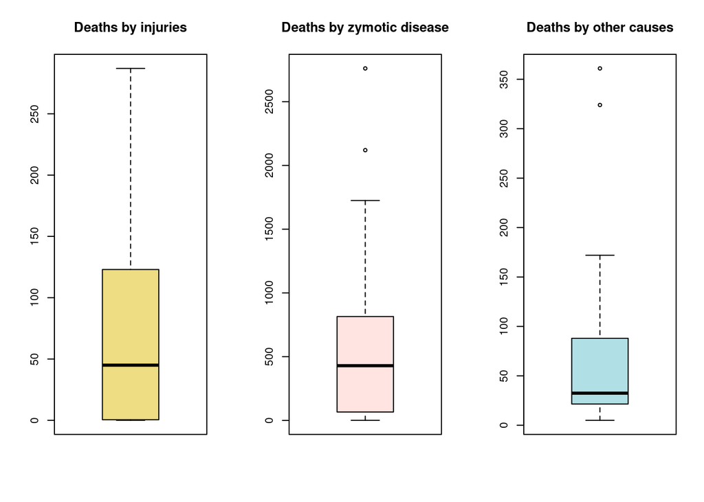

By looking at the plots above:

- The majority of deaths by injuries are compressed between 0 and 130, approximately. Additionally, there are some exceptional periods where deaths by injury amounted up to 300.
- Most of deaths by zymotic diseases are compressed between 50 and 800, approximately. However, we can see a long tail of cases up to 1700, with some additional outliers of 2100 and 2800.
- The majority of deaths by other alternative causes are compressed between 25 and 75, approximately. We can also appreciate a long tail up to 175 and some outliers of 300 and 350.

To sum up, it seems for now that most of the deaths included in our dataset were caused by zymotic diseases.

## 2.3 Feature Engineering

As the periods in our dataset are prior to January 1900, R cannot handle them as proper dates. For this reason, we are going to treat time as a numeric variable taking integer value from 0 to 23 in chronological order. This table of equivalences may be useful for the interpretation of the results in this report.

**Time periods**

Equivalence between both variables

| month | time_period |
| --- | --- |
| Apr 1854 | 0 |
| May 1854 | 1 |
| Jun 1854 | 2 |
| Jul 1854 | 3 |
| Aug 1854 | 4 |
| Sep 1854 | 5 |
| Oct 1854 | 6 |
| Nov 1854 | 7 |
| Dec 1854 | 8 |
| Jan 1855 | 9 |
| Feb 1855 | 10 |
| Mar 1855 | 11 |
| Apr 1855 | 12 |
| May 1855 | 13 |
| Jun 1855 | 14 |
| Jul 1855 | 15 |
| Aug 1855 | 16 |
| Sep 1855 | 17 |
| Oct 1855 | 18 |
| Nov 1855 | 19 |
| Dec 1855 | 20 |
| Jan 1856 | 21 |
| Feb 1856 | 22 |
| Mar 1856 | 23 |

.

Taking into consideration that the first data we have is from April 1854 and the last one from March 1856, this completes two whole years, accounted in a monthly basis, and no month is missing. As we have already mentioned, this does not come as a surprise as we have already observed that our dataset consists of 24 rows.

In order to have a better understanding of the data presented, we created a new variable which contains the sum of the different death causes (zymotic, injuries and other) combined. Each entry of this variable will be seggregated by period/month of the year. The name of this new variable is “total_deaths”.

In addition, we created another new variable that aims to explain the cumulative deaths over time. Thus, using the new variable of deaths generated just before, we create a new one in order to explain how this aggregated deaths perform over time. The name of this variable is “cum_deaths”.

| Month | TotalDeaths | TimePeriod |
| --- | --- | --- |
| Jan 1855 | 3168 | 9 |
| Feb 1855 | 2523 | 10 |
| Dec 1854 | 1970 | 8 |
| Mar 1855 | 1409 | 11 |
| Nov 1854 | 1237 | 7 |
| Jun 1855 | 1042 | 14 |
| Sep 1854 | 939 | 5 |
| Aug 1854 | 859 | 4 |
| Oct 1854 | 763 | 6 |
| Aug 1855 | 672 | 16 |
| May 1855 | 594 | 13 |
| Apr 1855 | 582 | 12 |
| Jul 1855 | 549 | 15 |
| Sep 1855 | 485 | 17 |
| Jul 1854 | 382 | 3 |
| Nov 1855 | 243 | 19 |
| Oct 1855 | 199 | 18 |
| Dec 1855 | 137 | 20 |
| Jan 1856 | 92 | 21 |
| Mar 1856 | 50 | 23 |
| Feb 1856 | 43 | 22 |
| May 1854 | 21 | 1 |
| Jun 1854 | 17 | 2 |
| Apr 1854 | 6 | 0 |

The above table shows our dataset but sorted by the number of total deaths in descending order. We can observe that the time period with the highest number of deaths is January 1855, the 10th time period in chronological order. Not surprisingly, April 1854, the first period in our dataset, is the one with the fewest deaths.

## 2.4 Seasonality Analysis

As we are working with time series, we must first check for stationarity in the data. Depending on whether the variables present a seasonal component or not, the analysis techniques and their interpretations will differ.

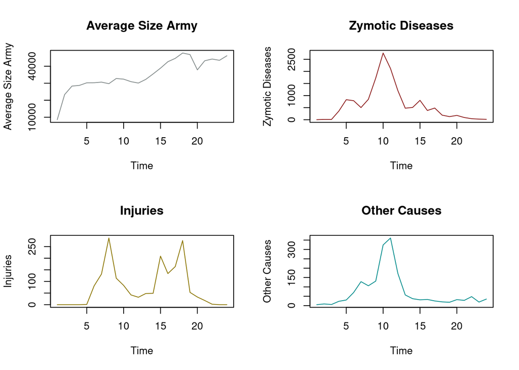

After visually inspecting the four main series, we can state that no seasonal components are observable in any of them. Hence, we will assume that neither of our variables have seasonal effects.

# 3 Data Visualization

Florence Nightingale is famous for its polar-area diagrams, as mentioned earlier. This kind of plots, where she represented the different causes of mortality among British soldiers, were then named Nightingale rose plots in her honor. The image below show the original plots made by her in 1856 with data collected during the Crimean War.

[figure not shown]

Nightingale Rose Plot

In this section, we are going to explore the dataset in a visual way to see the impacts some variables had on some others using a different approach than Nightingale’s. We first plot three barplots, one per each cause of death:

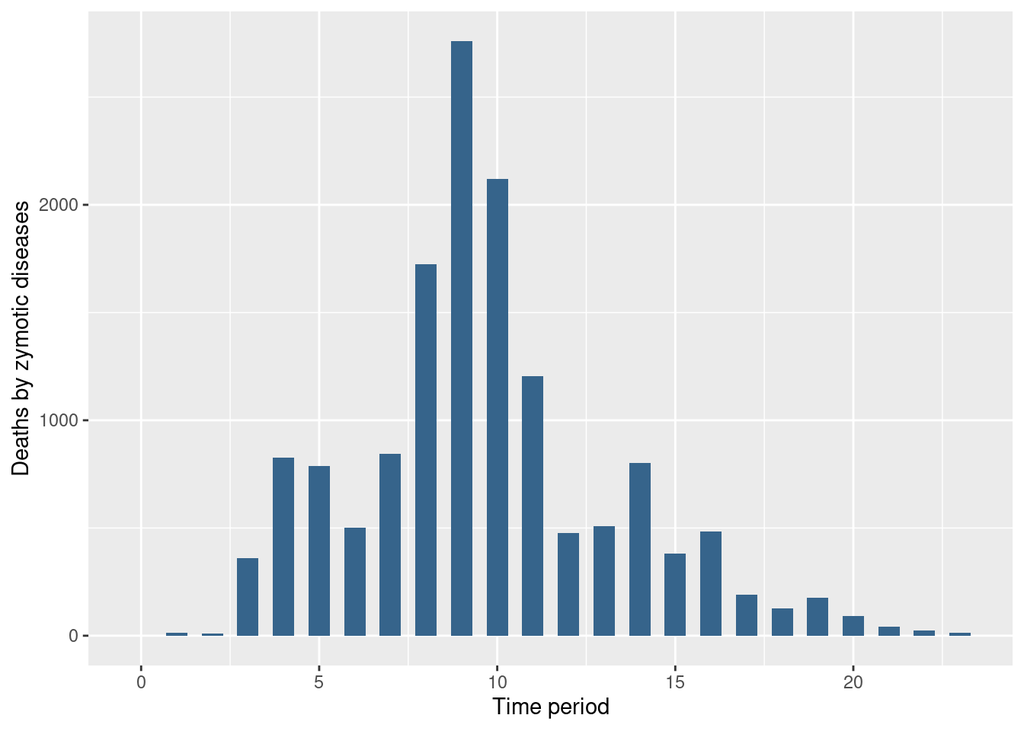

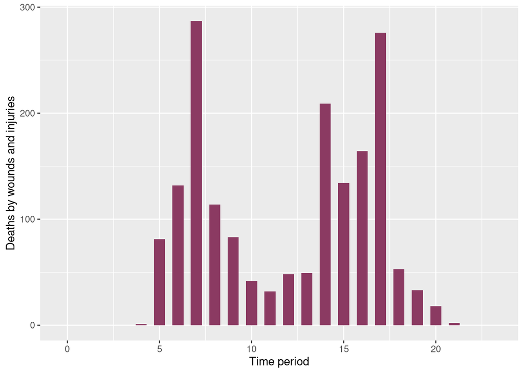

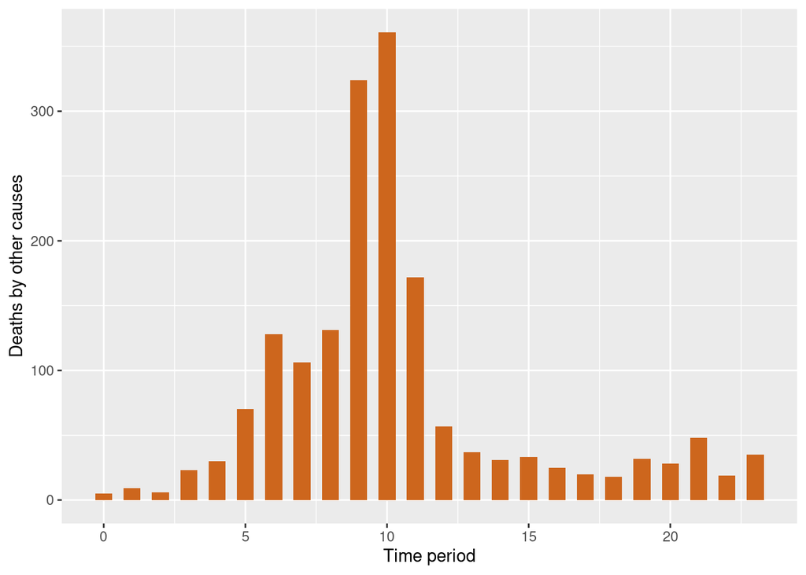

The following plot is an interactive graph that shows the evolution of the three series (zymotic diseases, injuries and other) depicted all together:

[interactive chart not shown]

[interactive chart not shown]

As expected, the results achieved are very similar than in the graph above.

[interactive chart not shown]

Despite the high amount of deaths observed in the graphs above, especially in period 9, the size of the army keeps increasing, generally, month after month. This can be caused by some hidden information not captured by the variables given in the dataset, such as for example the incorporation of new soldiers during the war to substitute their dead counterparts.

[interactive chart not shown]

# 4 Regression Analysis

The aim of this section is to understand the relationship between variables. We start by studying the correlation coefficient between two variables. Morever, we explore through different regression models whether one of these variables has a significant impact on the other variable.

As the variables in our data set represent time series, some degree of autocorrelation within each variable is expected. For this reason, and to be able to better assess the statistical significance of the variables when used in regression models, standard errors are computed using the Newey West method, which accounts for this autocorrelation.

We have also analyzed the normality of the residuals after fitting the model and discarded those models with non-normal residuals. Normality is checked graphically with a QQPlot and running the Shapiro-Wilk test (null hypothesis: normality). For the interpretation of this test and for when assessing statistical significance of coefficients, we set a 0.05 (5%) significance level.

This HTML report only includes the regression models that, after being fitting, had normally distributed residuals.

## 4.1 Average size army vs Deaths by injuries

```
## [1] 0.2467519
```

```
##
## t test of coefficients:
##
##              Estimate Std. Error t value  Pr(>|t|)
## (Intercept) 33089.206   3302.452 10.0196 1.165e-09 ***
## injuries       25.762     27.248  0.9455    0.3547
## ---
## Signif. codes:  0 '***' 0.001 '**' 0.01 '*' 0.05 '.' 0.1 ' ' 1
```

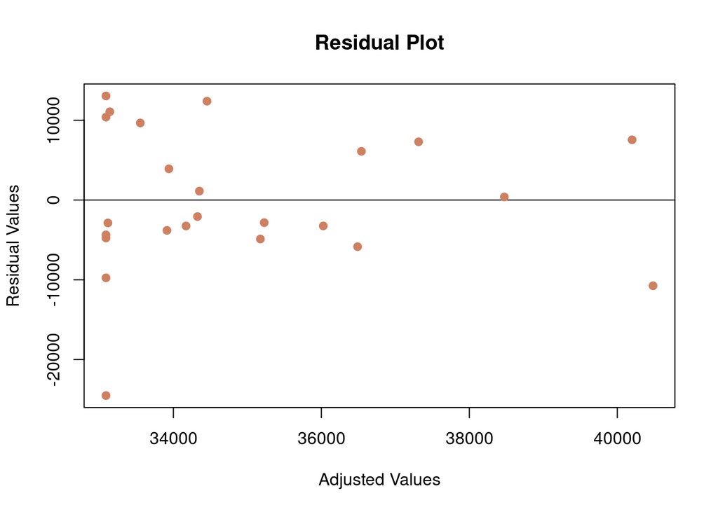

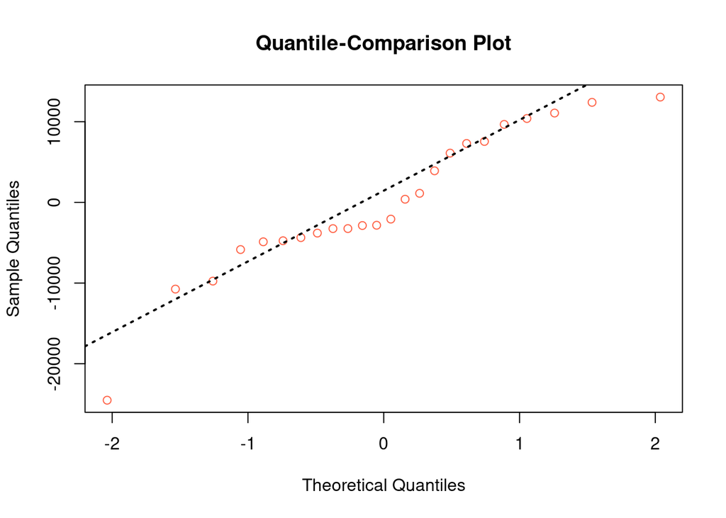

```
##
##  Shapiro-Wilk normality test
##
## data:  resid2
## W = 0.92936, p-value = 0.09431
```

```
##
## Call:
## lm(formula = avg_size_army ~ injuries, data = data)
##
## Residuals:
##    Min     1Q Median     3Q    Max
## -24518  -4464  -2454   7363  13051
##
## Coefficients:
##             Estimate Std. Error t value Pr(>|t|)
## (Intercept) 33089.21    2422.42  13.660 3.18e-12 ***
## injuries       25.76      21.57   1.194    0.245
## ---
## Signif. codes:  0 '***' 0.001 '**' 0.01 '*' 0.05 '.' 0.1 ' ' 1
##
## Residual standard error: 8995 on 22 degrees of freedom
## Multiple R-squared:  0.06089,    Adjusted R-squared:  0.0182
## F-statistic: 1.426 on 1 and 22 DF,  p-value: 0.2451
```

The correlation coefficient between deaths by injuries and the average size of the army is aprox 0.25, slightly low but positive.

The adjusted R-squared takes the value 0.02, approximately, showing a poor goodness of fit of this model.

## 4.2 Average size army vs. All deaths (multilinear regression model)

```
##
## t test of coefficients:
##
##                 Estimate Std. Error t value  Pr(>|t|)
## (Intercept)   34417.1955  4161.3598  8.2707 6.945e-08 ***
## data$zymotic     -4.6268     6.5790 -0.7033     0.490
## data$injuries    31.9714    24.6833  1.2953     0.210
## data$other       13.8388    36.8189  0.3759     0.711
## ---
## Signif. codes:  0 '***' 0.001 '**' 0.01 '*' 0.05 '.' 0.1 ' ' 1
```

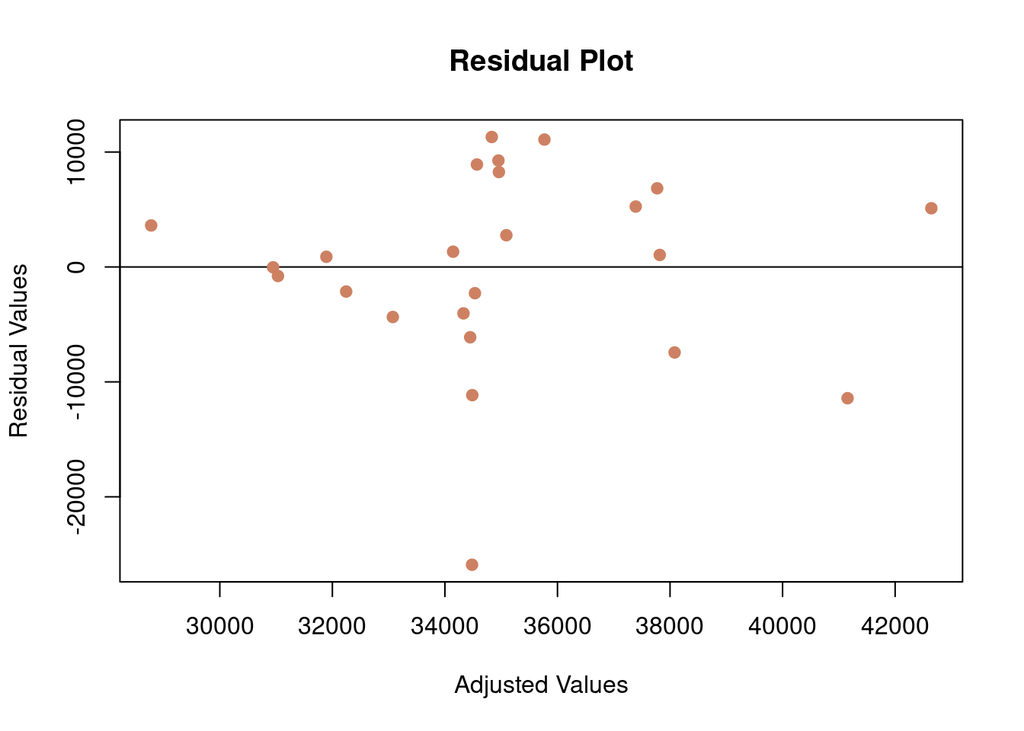

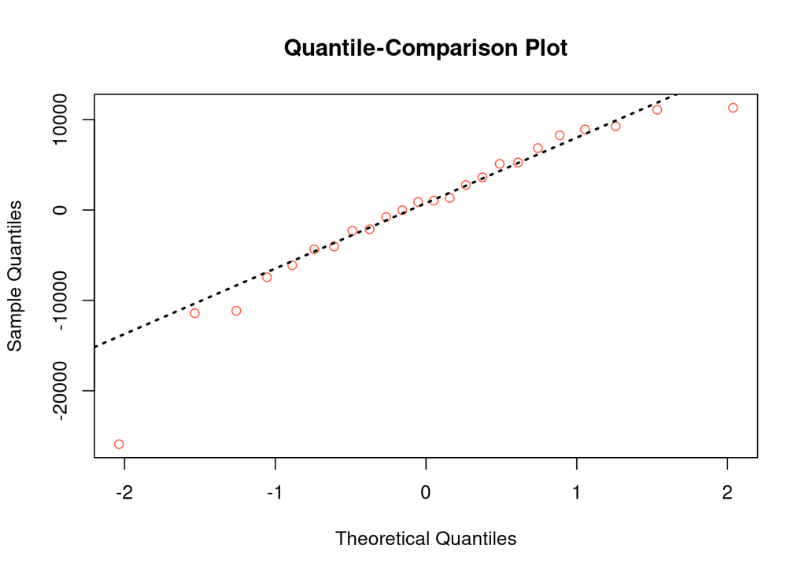

```
##
##  Shapiro-Wilk normality test
##
## data:  resid4
## W = 0.92138, p-value = 0.06268
```

```
##
## Call:
## lm(formula = avg_size_army ~ data$zymotic + data$injuries + data$other,
##     data = data)
##
## Residuals:
##      Min       1Q   Median       3Q      Max
## -25910.8  -4117.9    965.4   5652.9  11307.8
##
## Coefficients:
##                Estimate Std. Error t value Pr(>|t|)
## (Intercept)   34417.196   2819.689  12.206 1.01e-10 ***
## data$zymotic     -4.627      6.392  -0.724    0.478
## data$injuries    31.971     22.935   1.394    0.179
## data$other       13.839     48.053   0.288    0.776
## ---
## Signif. codes:  0 '***' 0.001 '**' 0.01 '*' 0.05 '.' 0.1 ' ' 1
##
## Residual standard error: 9148 on 20 degrees of freedom
## Multiple R-squared:  0.1171, Adjusted R-squared:  -0.01533
## F-statistic: 0.8842 on 3 and 20 DF,  p-value: 0.4661
```

Despite the previous results, when we regress the average size of the army against all three causes of death in the dataset, we obtain that the fitted model has normally distributed residuals.

Nonetheless, neither of the coefficients are statistically significant, allowing us to conclude that neither deaths by injuries, deaths by zymotic diseases nor deaths by other causes appear to have a significant effect on the average size of the army.

This may appear surprising, as we would expect that the more deaths (no matter the cause), the lower the average size of the army. However, we must also bear in mind that the variables in the dataset do not explain the whole story. The dataset does not include information of the new soldiers that month after month joined the army. Having soldiers killed may cause the average size of the army to decrease but it may also caused more men to join the army, increasing its average size. Without information of new soldiers, we cannot know the real impact of the causes of death on the average size of the army.

Moreover, the very low (and even negative in this case) adjusted R-squared shows that this model does not fit our data very well.

# 5 Predictions

The models presented in the previous section as reliable models are the ones chosen for making predictions of future values. The training set corresponds to the first 70% of observations from the original dataset whereas the remaining 30% are treated as the test or validation set. The loss function we choose to minimize and use to determine the accuracy of our prediction models is the root mean squared error.

## 5.1 Predicting the average size of the army from deaths by injuries

This first prediction model attempts to predict the average size of the army from the deaths by injuries. After testing the fitted model on the data set aside for testing, we obtain the following value for the root mean squared error:

```
## [1] 274262
```

## 5.2 Predicting the average size of the army from all causes of death

This second prediction model attempts to predict the average size of the army but now from all death causes: injuries, zymotic diseases and other causes. The following root mean squared error is obtained when comparing the predictions with the test data:

```
## [1] 278387.9
```

For both prediction models, the resulting root mean squared errors are extremely large. Thus, we can state that the results of both predictions are not accurate. One would blame such bad results on the low significance of predictors, as the previous section showed. However, when predicting future values of a variable we are not concerned with significance but rather with best fit.

Hence, getting low accuracy prediction models is due to the small size of the dataset and the number of variables we are working with. Perhaps we would have obtained more reliable results if we had more variables in our dataset or just a greater number of observations.

# 6 Conclusions

We conclude this project with the following findings and highlights:

- We discovered that the most predominant cause of death among soldiers was zymotic diseases. Zymotic diseases are infectious diseases that were spread in war hospitals due to bad hygenic conditions. Nightingale, after finding out and with her graphs and data as evidence, denounced this issue to the British parliament. These results are undoubtedly suprising as when considering deaths of war soldiers one would expect the number one cause of death to be injuries and wounds at combat.
- Between the other two causes of death she took into consideration, injuries and other causes, the difference is not really apparent.
- We can appreciate sudden increases in the data on average size of army although deaths are high. As we have already discussed, one could assume that larger deaths caused the size of the army to move in two opposite directions. On the one hand, more deaths caused the size of the army to decrease. On the other hand, the larger the number of deaths, the more new soldiers that were recruited to join the army, making the average size of the army to increase. Apparently, this last effect was stronger than the first one. Nevertheless, we do not have data to sustain this theory and to calculate the exact impact these two effects had.

Besides, it is very important to take into account the moment in history the data was collected (1854-1856) to better understand Nightingale’s data analysis techniques as well as the lack of information/other relevant variables. Due to this fact, it is difficult to identify clear patterns in the overall data and to obtain unbiased, reliable and well-fitted regression models.

Moreover, the small size of the dataset poses a problem when trying to predict future values as the accuracy obtained is extremely low judging by the resulting root mean squared error values.

# 7 Web References

Useful links to learn more about Florence Nightingale and her legacy:

https://theconversation.com/the-healing-power-of-data-florence-nightingales-true-legacy-134649

https://www.history.com/topics/womens-history/florence-nightingale-1

https://mujeresconciencia.com/2017/08/22/florence-nightingale-mucho-mas-la-dama-la-lampara/

http://www.eyemagazine.com/feature/article/lady-with-the-diagram